# **Assignment 04**

## May 03, 2023

## **Part 1**

Question 1: Read in the series 'A.csv', 'B.csv', 'C.csv'

```python
#Load necessary packages
import pandas as pd
import matplotlib.pyplot as plt
from matplotlib import pyplot
from numpy import polyfit
from pandas import read_csv
from statsmodels.tsa.api import VAR
import statsmodels.api as sm
from statsmodels.tsa.vector_ar.var_model import VARResults
import numpy as np
from pandas import DataFrame
from statsmodels.tsa.stattools import grangercausalitytests
from statsmodels.tsa.vector_ar.vecm import*
```

```python
dataA = read_csv("/content/A.csv", header=0, index_col=0)
dataA.head()
```

|  | 0 |
| --- | --- |
| 0 | 0.000000 |
| 1 | 0.000000 |
| 2 | -1.690123 |
| 3 | -1.219096 |
| 4 | -1.410304 |

```python
dataB = read_csv("/content/B.csv", header=0, index_col=0)
dataB.head()
```

|  | 0 |
| --- | --- |
| 0 | 0.000000 |
| 1 | 0.000000 |
| 2 | -0.809757 |
| 3 | -0.412396 |
| 4 | -2.072510 |

```python
dataC = read_csv("/content/C.csv", header=0, index_col=0)
dataC.head()
```

|  | 0 |
| --- | --- |
| 0 | 0.000000 |
| 1 | 0.000000 |
| 2 | 0.420383 |
| 3 | -2.200924 |
| 4 | -1.201323 |

Question 2: Plot the data and observe

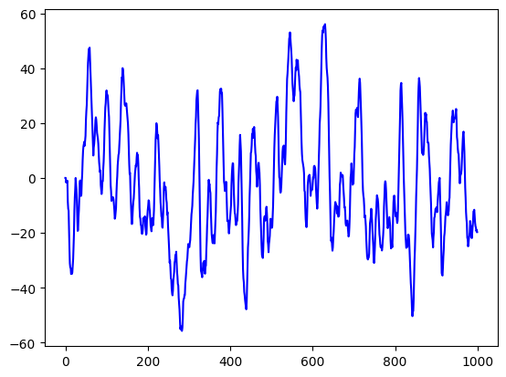

```python
pyplot.plot(dataA, color = "blue")
```

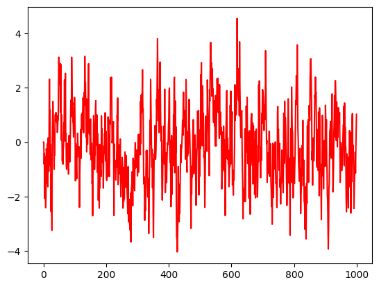

```python
pyplot.plot(dataB, color = "red")
```

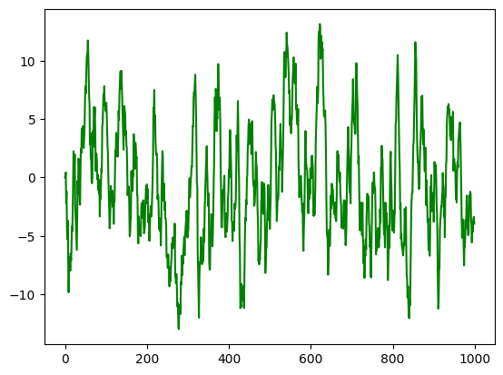

```python
pyplot.plot(dataC, color = "green")
```

Question 3: DataFrame the series and create a VAR model

```python
#Create dataframe
df_A = pd.read_csv("A.csv", index_col = 0)
df_B = pd.read_csv("B.csv", index_col = 0)
df_C = pd.read_csv("C.csv", index_col = 0)

#Rename columns in df_B and df_C
B_data_renamed = df_B.rename(columns={'0': '1'})
C_data_renamed = df_C.rename(columns={'0': '2'})

#Combine the DataFrames
df = pd.concat([df_A, B_data_renamed['1'], C_data_renamed['2']], axis=1)
print(df)
```

```
             0         1         2
0     0.000000  0.000000  0.000000
1     0.000000  0.000000  0.000000
2    -1.690123 -0.809757  0.420383
3    -1.219096 -0.412396 -2.200924
4    -1.410304 -2.072510 -1.201323
..         ...       ...       ...
995 -17.606319 -0.376287 -4.681310
996 -18.148384 -1.141380 -3.754667
997 -19.441957 -0.247277 -3.524234
998 -18.939188  0.408352 -3.379407
999 -19.760931  1.023867 -3.971483

[1000 rows x 3 columns]
```

```python
# create a VAR model
from statsmodels.tsa.api import VAR

model = VAR(df)
```

Question 4: Determine optimum lag order (p) by either: Lag order selection or Perform model fits at different lag orders to find lowest AIC.

```
   I choose the first option, which is to lag order selection.
```

```python
#Lag order selection
lag_order = model.select_order(15)
print(lag_order.summary())
```

```
 VAR Order Selection (* highlights the minimums)
==================================================
       AIC         BIC         FPE         HQIC
--------------------------------------------------
0        8.543       8.558       5131.       8.549
1       0.2952      0.3548       1.343      0.3179
2     0.02932*     0.1336*      1.030*    0.06900*
3      0.03951      0.1885       1.040     0.09619
4      0.04831      0.2420       1.049      0.1220
5      0.05904      0.2975       1.061      0.1497
6      0.07068      0.3538       1.073      0.1784
7      0.08682      0.4147       1.091      0.2115
8      0.09559      0.4681       1.100      0.2373
9      0.09996      0.5172       1.105      0.2587
10      0.1029      0.5649       1.108      0.2786
11      0.1147      0.6213       1.122      0.3074
12      0.1244      0.6758       1.133      0.3342
13      0.1273      0.7234       1.136      0.3540
14      0.1357      0.7765       1.146      0.3794
15      0.1421      0.8276       1.153      0.4028
--------------------------------------------------
```

The preceding result shows that our lag order is 2.

Question 5: Model fit at optimum lag order and get results

```python
results = model.fit(2)
print()
print(results.summary())
```

```
  Summary of Regression Results
==================================
Model:                         VAR
Method:                        OLS
Date:           Fri, 05, May, 2023
Time:                     05:12:06
--------------------------------------------------------------------
No. of Equations:         3.00000    BIC:                   0.150727
Nobs:                     998.000    HQIC:                 0.0867368
Log likelihood:          -4251.00    FPE:                    1.04865
AIC:                    0.0474994    Det(Omega_mle):         1.02689
--------------------------------------------------------------------
Results for equation 0
========================================================================
           coefficient       std. error           t-stat            prob
------------------------------------------------------------------------
const        -0.021805         0.032702           -0.667           0.505
L1.0          0.506941         0.029924           16.941           0.000
L1.1          0.019381         0.032257            0.601           0.548
L1.2          1.036461         0.030445           34.044           0.000
L2.0          0.193430         0.023225            8.329           0.000
L2.1         -0.025070         0.048421           -0.518           0.605
L2.2          0.473736         0.043417           10.911           0.000
========================================================================

Results for equation 1
========================================================================
           coefficient       std. error           t-stat            prob
------------------------------------------------------------------------
const        -0.036670         0.031897           -1.150           0.250
L1.0          0.019310         0.029188            0.662           0.508
L1.1          0.537018         0.031463           17.068           0.000
L1.2          0.043410         0.029695            1.462           0.144
L2.0         -0.013094         0.022653           -0.578           0.563
L2.1          0.175581         0.047229            3.718           0.000
L2.2         -0.066610         0.042348           -1.573           0.116
========================================================================

Results for equation 2
========================================================================
           coefficient       std. error           t-stat            prob
------------------------------------------------------------------------
const         0.050121         0.032059            1.563           0.118
L1.0          0.009646         0.029335            0.329           0.742
L1.1          0.992979         0.031622           31.401           0.000
L1.2          0.475025         0.029846           15.916           0.000
L2.0         -0.009907         0.022768           -0.435           0.663
L2.1          0.514944         0.047468           10.848           0.000
L2.2          0.222129         0.042562            5.219           0.000
========================================================================

Correlation matrix of residuals
            0         1         2
0    1.000000 -0.050210  0.011697
1   -0.050210  1.000000 -0.000741
2    0.011697 -0.000741  1.000000
```

Question 6: Use results to find roots (number of roots = K*p)

```python
nroots = 3 * 2
print("Roots = ")
for i in range(0, nroots) :
  print(results.roots[i])

print("Moduli = ")
for i in range(0, nroots) :
  print(np.absolute(results.roots[i]))
```

```
Roots =
(-5.038356099006577-0j)
(-2.7597975398912276+0.9514553898601947j)
(-2.7597975398912276-0.9514553898601947j)
(1.29510203359811+0.2445593762766888j)
(1.29510203359811-0.2445593762766888j)
(1.1440891999704326-0j)
Moduli =
5.038356099006577
2.9192036277183004
2.9192036277183004
1.317990351237369
1.317990351237369
1.1440891999704326
```

Question 7: Observe the roots. Is the model stationary?

Since all the absolute values of roots are greater than 1, our model is **stationary**

Question 8: If stationary, investigate Granger causality between series combinations (if any)

```python
df_1 = pd.concat([dataA, dataB], axis=1)
grangercausalitytests(df_1, 3)
```

```
Granger Causality
number of lags (no zero) 1
ssr based F test:         F=392.7695, p=0.0000  , df_denom=996, df_num=1
ssr based chi2 test:   chi2=393.9525, p=0.0000  , df=1
likelihood ratio test: chi2=332.0937, p=0.0000  , df=1
parameter F test:         F=392.7695, p=0.0000  , df_denom=996, df_num=1

Granger Causality
number of lags (no zero) 2
ssr based F test:         F=322.8985, p=0.0000  , df_denom=993, df_num=2
ssr based chi2 test:   chi2=649.0487, p=0.0000  , df=2
likelihood ratio test: chi2=499.9850, p=0.0000  , df=2
parameter F test:         F=322.8985, p=0.0000  , df_denom=993, df_num=2

Granger Causality
number of lags (no zero) 3
ssr based F test:         F=362.6217, p=0.0000  , df_denom=990, df_num=3
ssr based chi2 test:   chi2=1095.5571, p=0.0000  , df=3
likelihood ratio test: chi2=739.1671, p=0.0000  , df=3
parameter F test:         F=362.6217, p=0.0000  , df_denom=990, df_num=3
```

```
{1: ({'ssr_ftest': (392.76945207218614, 6.0142896769342264e-74, 996.0, 1),
   'ssr_chi2test': (393.95249259047586, 1.1413683085281775e-87, 1),
   'lrtest': (332.0936640736454, 3.363479848093831e-74, 1),
   'params_ftest': (392.76945207218637, 6.0142896769337135e-74, 996.0, 1.0)},
  [<statsmodels.regression.linear_model.RegressionResultsWrapper at 0x7fa3f1846a40>,
   <statsmodels.regression.linear_model.RegressionResultsWrapper at 0x7fa3f1847700>,
   array([[0., 1., 0.]])]),
 2: ({'ssr_ftest': (322.8984646015282, 9.409555871099256e-109, 993.0, 2),
   'ssr_chi2test': (649.0486760771906, 1.1504579420229072e-141, 2),
   'lrtest': (499.9850338019128, 2.689238950068241e-109, 2),
   'params_ftest': (322.8984646015277, 9.409555871103e-109, 993.0, 2.0)},
  [<statsmodels.regression.linear_model.RegressionResultsWrapper at 0x7fa3f18469e0>,
   <statsmodels.regression.linear_model.RegressionResultsWrapper at 0x7fa3f1847640>,
   array([[0., 0., 1., 0., 0.],
          [0., 0., 0., 1., 0.]])]),
 3: ({'ssr_ftest': (362.6217066196527, 7.564754388360088e-159, 990.0, 3),
   'ssr_chi2test': (1095.5570954539205, 3.34929082389205e-237, 3),
   'lrtest': (739.1671438367075, 6.742048313468656e-160, 3),
   'params_ftest': (362.62170661965257, 7.564754388360088e-159, 990.0, 3.0)},
  [<statsmodels.regression.linear_model.RegressionResultsWrapper at 0x7fa3f1845510>,
   <statsmodels.regression.linear_model.RegressionResultsWrapper at 0x7fa3f18454b0>,
   array([[0., 0., 0., 1., 0., 0., 0.],
          [0., 0., 0., 0., 1., 0., 0.],
          [0., 0., 0., 0., 0., 1., 0.]])])}
```

```python
df_2 = pd.concat([dataB, dataA], axis=1)
grangercausalitytests(df_2, 3)
```

```
Granger Causality
number of lags (no zero) 1
ssr based F test:         F=3.0198  , p=0.0826  , df_denom=996, df_num=1
ssr based chi2 test:   chi2=3.0289  , p=0.0818  , df=1
likelihood ratio test: chi2=3.0243  , p=0.0820  , df=1
parameter F test:         F=3.0198  , p=0.0826  , df_denom=996, df_num=1

Granger Causality
number of lags (no zero) 2
ssr based F test:         F=0.1399  , p=0.8694  , df_denom=993, df_num=2
ssr based chi2 test:   chi2=0.2813  , p=0.8688  , df=2
likelihood ratio test: chi2=0.2812  , p=0.8688  , df=2
parameter F test:         F=0.1399  , p=0.8694  , df_denom=993, df_num=2

Granger Causality
number of lags (no zero) 3
ssr based F test:         F=1.4656  , p=0.2224  , df_denom=990, df_num=3
ssr based chi2 test:   chi2=4.4277  , p=0.2188  , df=3
likelihood ratio test: chi2=4.4179  , p=0.2197  , df=3
parameter F test:         F=1.4656  , p=0.2224  , df_denom=990, df_num=3
```

```
{1: ({'ssr_ftest': (3.0198106082919587, 0.08256215465647816, 996.0, 1),
   'ssr_chi2test': (3.0289064233771756, 0.0817931277158338, 1),
   'lrtest': (3.0243239547589837, 0.08202449929611362, 1),
   'params_ftest': (3.0198106082920244, 0.08256215465647816, 996.0, 1.0)},
  [<statsmodels.regression.linear_model.RegressionResultsWrapper at 0x7fa3f1825de0>,
   <statsmodels.regression.linear_model.RegressionResultsWrapper at 0x7fa3f1826d10>,
   array([[0., 1., 0.]])]),
 2: ({'ssr_ftest': (0.13993308301704652, 0.8694335534094016, 993.0, 2),
   'ssr_chi2test': (0.2812753612306393, 0.8688040392231824, 2),
   'lrtest': (0.28123573148741343, 0.8688212546342364, 2),
   'params_ftest': (0.1399330830170719, 0.8694335534094016, 993.0, 2.0)},
  [<statsmodels.regression.linear_model.RegressionResultsWrapper at 0x7fa3f1824850>,
   <statsmodels.regression.linear_model.RegressionResultsWrapper at 0x7fa3f1825cc0>,
   array([[0., 0., 1., 0., 0.],
          [0., 0., 0., 1., 0.]])]),
 3: ({'ssr_ftest': (1.4655529457939496, 0.22239460858460164, 990.0, 3),
   'ssr_chi2test': (4.427746324110811, 0.21882640777510012, 3),
   'lrtest': (4.417943372472109, 0.21972737592450597, 3),
   'params_ftest': (1.4655529457938734, 0.22239460858463725, 990.0, 3.0)},
  [<statsmodels.regression.linear_model.RegressionResultsWrapper at 0x7fa3f18249a0>,
   <statsmodels.regression.linear_model.RegressionResultsWrapper at 0x7fa3f18279a0>,
   array([[0., 0., 0., 1., 0., 0., 0.],
          [0., 0., 0., 0., 1., 0., 0.],
          [0., 0., 0., 0., 0., 1., 0.]])])}
```

```python
df_3 = pd.concat([dataB, dataC], axis=1)
grangercausalitytests(df_3, 3)
```

```
Granger Causality
number of lags (no zero) 1
ssr based F test:         F=16.3795 , p=0.0001  , df_denom=996, df_num=1
ssr based chi2 test:   chi2=16.4288 , p=0.0001  , df=1
likelihood ratio test: chi2=16.2952 , p=0.0001  , df=1
parameter F test:         F=16.3795 , p=0.0001  , df_denom=996, df_num=1

Granger Causality
number of lags (no zero) 2
ssr based F test:         F=1.1996  , p=0.3018  , df_denom=993, df_num=2
ssr based chi2 test:   chi2=2.4112  , p=0.2995  , df=2
likelihood ratio test: chi2=2.4083  , p=0.2999  , df=2
parameter F test:         F=1.1996  , p=0.3018  , df_denom=993, df_num=2

Granger Causality
number of lags (no zero) 3
ssr based F test:         F=1.0361  , p=0.3757  , df_denom=990, df_num=3
ssr based chi2 test:   chi2=3.1304  , p=0.3720  , df=3
likelihood ratio test: chi2=3.1255  , p=0.3727  , df=3
parameter F test:         F=1.0361  , p=0.3757  , df_denom=990, df_num=3
```

```
{1: ({'ssr_ftest': (16.379480774348448, 5.585892324377785e-05, 996.0, 1),
   'ssr_chi2test': (16.428816559813352, 5.051148016287925e-05, 1),
   'lrtest': (16.29519147434985, 5.4201318493818766e-05, 1),
   'params_ftest': (16.379480774348544, 5.585892324377517e-05, 996.0, 1.0)},
  [<statsmodels.regression.linear_model.RegressionResultsWrapper at 0x7fa3f1827910>,
   <statsmodels.regression.linear_model.RegressionResultsWrapper at 0x7fa3f1827670>,
   array([[0., 1., 0.]])]),
 2: ({'ssr_ftest': (1.1995703737749566, 0.30175990608198855, 993.0, 2),
   'ssr_chi2test': (2.4112210131468412, 0.29950909141652077, 2),
   'lrtest': (2.408312877319986, 0.2999449147577086, 2),
   'params_ftest': (1.1995703737750256, 0.3017599060819696, 993.0, 2.0)},
  [<statsmodels.regression.linear_model.RegressionResultsWrapper at 0x7fa3f1827a60>,
   <statsmodels.regression.linear_model.RegressionResultsWrapper at 0x7fa3f1826bf0>,
   array([[0., 0., 1., 0., 0.],
          [0., 0., 0., 1., 0.]])]),
 3: ({'ssr_ftest': (1.0361281445703818, 0.37570577424909535, 990.0, 3),
   'ssr_chi2test': (3.1303629095050627, 0.37195922146735266, 3),
   'lrtest': (3.1254588429983414, 0.3726834513052497, 3),
   'params_ftest': (1.036128144570373, 0.3757057742491057, 990.0, 3.0)},
  [<statsmodels.regression.linear_model.RegressionResultsWrapper at 0x7fa3f1827040>,
   <statsmodels.regression.linear_model.RegressionResultsWrapper at 0x7fa3efa23f70>,
   array([[0., 0., 0., 1., 0., 0., 0.],
          [0., 0., 0., 0., 1., 0., 0.],
          [0., 0., 0., 0., 0., 1., 0.]])])}
```

```python
df_4 = pd.concat([dataC, dataB], axis=1)
grangercausalitytests(df_4, 3)
```

```
Granger Causality
number of lags (no zero) 1
ssr based F test:         F=1396.3028, p=0.0000  , df_denom=996, df_num=1
ssr based chi2 test:   chi2=1400.5085, p=0.0000  , df=1
likelihood ratio test: chi2=875.3882, p=0.0000  , df=1
parameter F test:         F=1396.3028, p=0.0000  , df_denom=996, df_num=1

Granger Causality
number of lags (no zero) 2
ssr based F test:         F=830.6571, p=0.0000  , df_denom=993, df_num=2
ssr based chi2 test:   chi2=1669.6793, p=0.0000  , df=2
likelihood ratio test: chi2=981.2445, p=0.0000  , df=2
parameter F test:         F=830.6571, p=0.0000  , df_denom=993, df_num=2

Granger Causality
number of lags (no zero) 3
ssr based F test:         F=511.7365, p=0.0000  , df_denom=990, df_num=3
ssr based chi2 test:   chi2=1546.0646, p=0.0000  , df=3
likelihood ratio test: chi2=933.5653, p=0.0000  , df=3
parameter F test:         F=511.7365, p=0.0000  , df_denom=990, df_num=3
```

```
{1: ({'ssr_ftest': (1396.3027704948283, 1.0046643851215782e-191, 996.0, 1),
   'ssr_chi2test': (1400.5085017312583, 1.6290355442605672e-306, 1),
   'lrtest': (875.3881613438762, 2.1989786962275603e-192, 1),
   'params_ftest': (1396.3027704948283, 1.0046643851215782e-191, 996.0, 1.0)},
  [<statsmodels.regression.linear_model.RegressionResultsWrapper at 0x7fa3f4e9da80>,
   <statsmodels.regression.linear_model.RegressionResultsWrapper at 0x7fa3f4e9e7a0>,
   array([[0., 1., 0.]])]),
 2: ({'ssr_ftest': (830.6570651119692, 9.839555417953493e-213, 993.0, 2),
   'ssr_chi2test': (1669.679256760816, 0.0, 2),
   'lrtest': (981.2444830820396, 8.423019376061999e-214, 2),
   'params_ftest': (830.657065111965, 9.839555417968595e-213, 993.0, 2.0)},
  [<statsmodels.regression.linear_model.RegressionResultsWrapper at 0x7fa3ef9cf340>,
   <statsmodels.regression.linear_model.RegressionResultsWrapper at 0x7fa3f1844910>,
   array([[0., 0., 1., 0., 0.],
          [0., 0., 0., 1., 0.]])]),
 3: ({'ssr_ftest': (511.73652187542774, 9.874137585577581e-201, 990.0, 3),
   'ssr_chi2test': (1546.064582756974, 0.0, 3),
   'lrtest': (933.5652682501868, 4.6382548836016735e-202, 3),
   'params_ftest': (511.7365218754267, 9.874137585583755e-201, 990.0, 3.0)},
  [<statsmodels.regression.linear_model.RegressionResultsWrapper at 0x7fa3f1847e20>,
   <statsmodels.regression.linear_model.RegressionResultsWrapper at 0x7fa3f1844730>,
   array([[0., 0., 0., 1., 0., 0., 0.],
          [0., 0., 0., 0., 1., 0., 0.],
          [0., 0., 0., 0., 0., 1., 0.]])])}
```

```python
df_5 = pd.concat([dataA, dataC], axis=1)
grangercausalitytests(df_5, 3)
```

```
Granger Causality
number of lags (no zero) 1
ssr based F test:         F=10057.5224, p=0.0000  , df_denom=996, df_num=1
ssr based chi2 test:   chi2=10087.8161, p=0.0000  , df=1
likelihood ratio test: chi2=2404.3504, p=0.0000  , df=1
parameter F test:         F=10057.5224, p=0.0000  , df_denom=996, df_num=1

Granger Causality
number of lags (no zero) 2
ssr based F test:         F=2195.0923, p=0.0000  , df_denom=993, df_num=2
ssr based chi2 test:   chi2=4412.2903, p=0.0000  , df=2
likelihood ratio test: chi2=1686.9242, p=0.0000  , df=2
parameter F test:         F=2195.0923, p=0.0000  , df_denom=993, df_num=2

Granger Causality
number of lags (no zero) 3
ssr based F test:         F=1409.5274, p=0.0000  , df_denom=990, df_num=3
ssr based chi2 test:   chi2=4258.4812, p=0.0000  , df=3
likelihood ratio test: chi2=1657.2892, p=0.0000  , df=3
parameter F test:         F=1409.5274, p=0.0000  , df_denom=990, df_num=3
```

```
{1: ({'ssr_ftest': (10057.522401555507, 0.0, 996.0, 1),
   'ssr_chi2test': (10087.816143728867, 0.0, 1),
   'lrtest': (2404.3504107687418, 0.0, 1),
   'params_ftest': (10057.522401555507, 0.0, 996.0, 1.0)},
  [<statsmodels.regression.linear_model.RegressionResultsWrapper at 0x7fa3ef8acee0>,
   <statsmodels.regression.linear_model.RegressionResultsWrapper at 0x7fa3f1ed49a0>,
   array([[0., 1., 0.]])]),
 2: ({'ssr_ftest': (2195.0923348473298, 0.0, 993.0, 2),
   'ssr_chi2test': (4412.29033268406, 0.0, 2),
   'lrtest': (1686.9241504995698, 0.0, 2),
   'params_ftest': (2195.0923348473284, 0.0, 993.0, 2.0)},
  [<statsmodels.regression.linear_model.RegressionResultsWrapper at 0x7fa3f1846230>,
   <statsmodels.regression.linear_model.RegressionResultsWrapper at 0x7fa3f1846860>,
   array([[0., 0., 1., 0., 0.],
          [0., 0., 0., 1., 0.]])]),
 3: ({'ssr_ftest': (1409.5273751602804, 0.0, 990.0, 3),
   'ssr_chi2test': (4258.481191014544, 0.0, 3),
   'lrtest': (1657.2892491484672, 0.0, 3),
   'params_ftest': (1409.5273751602792, 0.0, 990.0, 3.0)},
  [<statsmodels.regression.linear_model.RegressionResultsWrapper at 0x7fa3f1847820>,
   <statsmodels.regression.linear_model.RegressionResultsWrapper at 0x7fa3f1847a60>,
   array([[0., 0., 0., 1., 0., 0., 0.],
          [0., 0., 0., 0., 1., 0., 0.],
          [0., 0., 0., 0., 0., 1., 0.]])])}
```

```python
df_6 = pd.concat([dataC, dataA], axis=1)
grangercausalitytests(df_6, 3)
```

```
Granger Causality
number of lags (no zero) 1
ssr based F test:         F=51.5885 , p=0.0000  , df_denom=996, df_num=1
ssr based chi2 test:   chi2=51.7439 , p=0.0000  , df=1
likelihood ratio test: chi2=50.4484 , p=0.0000  , df=1
parameter F test:         F=51.5885 , p=0.0000  , df_denom=996, df_num=1

Granger Causality
number of lags (no zero) 2
ssr based F test:         F=15.3064 , p=0.0000  , df_denom=993, df_num=2
ssr based chi2 test:   chi2=30.7669 , p=0.0000  , df=2
likelihood ratio test: chi2=30.3021 , p=0.0000  , df=2
parameter F test:         F=15.3064 , p=0.0000  , df_denom=993, df_num=2

Granger Causality
number of lags (no zero) 3
ssr based F test:         F=0.4617  , p=0.7091  , df_denom=990, df_num=3
ssr based chi2 test:   chi2=1.3948  , p=0.7067  , df=3
likelihood ratio test: chi2=1.3939  , p=0.7070  , df=3
parameter F test:         F=0.4617  , p=0.7091  , df_denom=990, df_num=3
```

```
{1: ({'ssr_ftest': (51.58851392973196, 1.3386221290206453e-12, 996.0, 1),
   'ssr_chi2test': (51.743901019881754, 6.323294244432849e-13, 1),
   'lrtest': (50.448391922524934, 1.2234000932016274e-12, 1),
   'params_ftest': (51.588513929732294, 1.3386221290205073e-12, 996.0, 1.0)},
  [<statsmodels.regression.linear_model.RegressionResultsWrapper at 0x7fa3f1845ae0>,
   <statsmodels.regression.linear_model.RegressionResultsWrapper at 0x7fa3f1846c20>,
   array([[0., 1., 0.]])]),
 2: ({'ssr_ftest': (15.306361362108195, 2.837521379738772e-07, 993.0, 2),
   'ssr_chi2test': (30.766865336120805, 2.0847792678292374e-07, 2),
   'lrtest': (30.302143814707506, 2.6301049322944197e-07, 2),
   'params_ftest': (15.306361362107499, 2.8375213797406873e-07, 993.0, 2.0)},
  [<statsmodels.regression.linear_model.RegressionResultsWrapper at 0x7fa3f1847dc0>,
   <statsmodels.regression.linear_model.RegressionResultsWrapper at 0x7fa3f1845ff0>,
   array([[0., 0., 1., 0., 0.],
          [0., 0., 0., 1., 0.]])]),
 3: ({'ssr_ftest': (0.461682401097439, 0.7091067248560956, 990.0, 3),
   'ssr_chi2test': (1.394840466345899, 0.7067445991402999, 3),
   'lrtest': (1.3938656583204647, 0.7069732830532804, 3),
   'params_ftest': (0.46168240109730757, 0.7091067248561732, 990.0, 3.0)},
  [<statsmodels.regression.linear_model.RegressionResultsWrapper at 0x7fa3f1845840>,
   <statsmodels.regression.linear_model.RegressionResultsWrapper at 0x7fa3f1846e60>,
   array([[0., 0., 0., 1., 0., 0., 0.],
          [0., 0., 0., 0., 1., 0., 0.],
          [0., 0., 0., 0., 0., 1., 0.]])])}
```

The preceding shows that

1. Series B is causing series A
2. Series A is not causing series B
3. Series C is not causing series B
4. Series B is causing series C
5. Series C is causing series A
6. Series A is causing series C

Question 9: Use IRF plots to confirm your causality conclusions

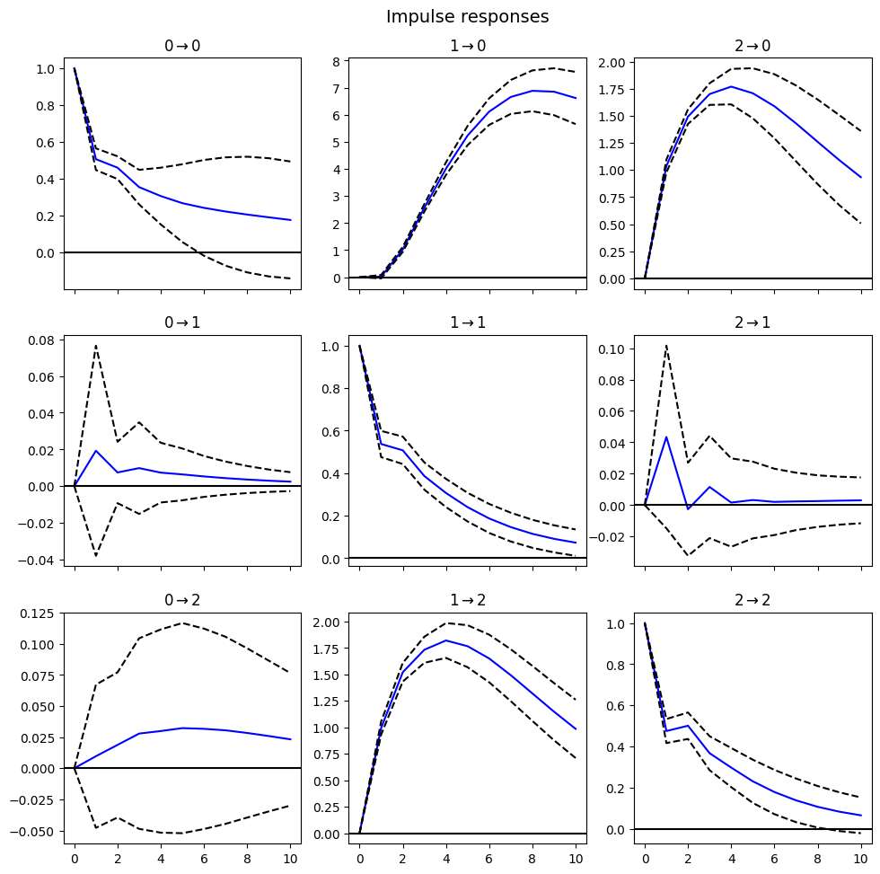

```python
irf = results.irf(10)
irf.plot(orth = False)
pyplot.show()
```

Question 10: Order the variables (list series in decreasing order of exogeneity)

1. B
2. C
3. A

Question 11: Whether VAR or VECM model, perform a dynamic forecast 10 steps forward and plot

```python
lag_order = results.k_ar
print()
print("Lag order =", lag_order)
forecast_values = results.forecast(df.values[-lag_order:], 10)
print()
print('Forecasted values:')
print(forecast_values)
```

```
Lag order = 2

Forecasted values:
[[-1.94104641e+01  5.03963569e-01 -1.36313418e+00]
 [-1.69942919e+01  5.03033660e-01 -4.43397126e-01]
 [-1.34996894e+01  3.19501467e-01  3.24082263e-01]
 [-1.00331316e+01  2.28675337e-01  7.20005734e-01]
 [-6.82304793e+00  1.34922583e-01  8.92680897e-01]
 [-4.15819446e+00  6.63481920e-02  9.19410233e-01]
 [-2.07581668e+00  1.21459016e-02  8.47997580e-01]
 [-5.65396328e-01 -2.85649275e-02  7.24565568e-01]
 [ 4.41898862e-01 -5.86457875e-02  5.75673601e-01]
 [ 1.03234165e+00 -8.05158007e-02  4.21448139e-01]]
```

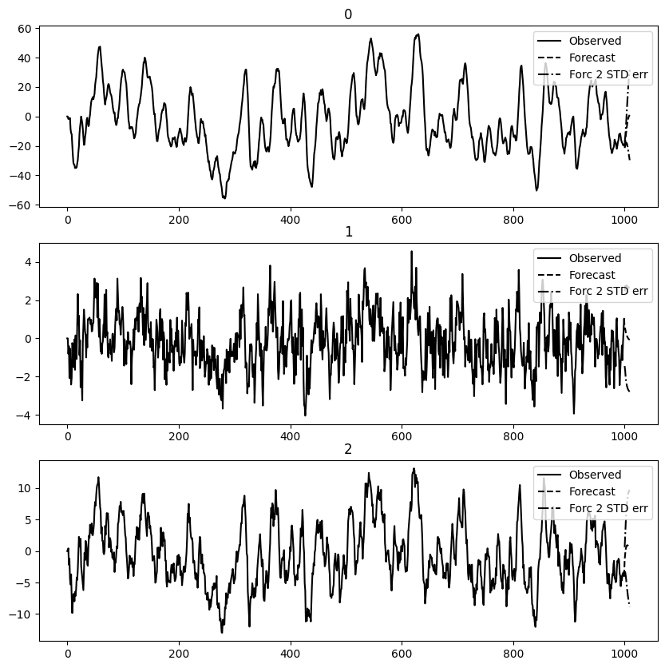

```python
results.plot_forecast(10)
pyplot.show()
```

# PART 2

Question 1: Read in the series 'X.csv', 'Y.csv', 'Z.csv'

```python
X = read_csv("/content/X.csv", header=0, index_col=0)
Y = read_csv("/content/Y.csv", header=0, index_col=0)
Z = read_csv("/content/Z.csv", header=0, index_col=0)
```

```python
X.head()
```

|  | 0 |
| --- | --- |
| 0 | 0.000000 |
| 1 | 0.000000 |
| 2 | -1.690123 |
| 3 | -1.298689 |
| 4 | -0.980425 |

```python
Y.head()
```

|  | 0 |
| --- | --- |
| 0 | 0.000000 |
| 1 | 0.000000 |
| 2 | -0.809757 |
| 3 | -2.972061 |
| 4 | -3.376950 |

```python
Z.head()
```

|  | 0 |
| --- | --- |
| 0 | 0.000000 |
| 1 | 0.000000 |
| 2 | 0.420383 |
| 3 | -0.759944 |
| 4 | -0.643369 |

Question 2: Plot the data and observe

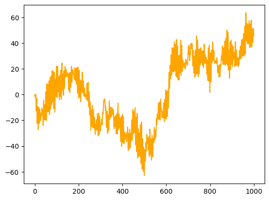

```python
pyplot.plot(X, color = "orange")
```

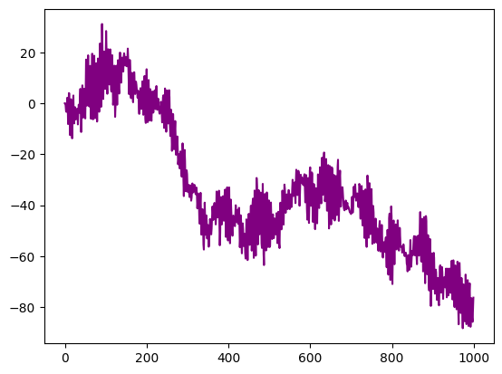

```python
pyplot.plot(Y, color = "purple")
```

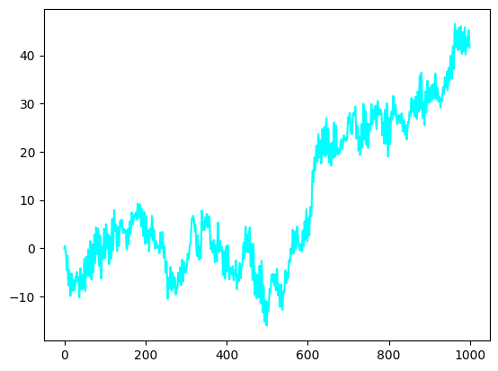

```python
pyplot.plot(Z, color = "cyan")
```

Question 3: DataFrame the series and create a VAR model

```python
#Create dataframes
X_df = pd.read_csv("X.csv", index_col = 0)
Y_df = pd.read_csv("Y.csv", index_col = 0)
Z_df = pd.read_csv("Z.csv", index_col = 0)

#Rename column names
Y_data_renamed = Y_df.rename(columns={'0': '1'})
Z_data_renamed = Z_df.rename(columns={'0': '2'})

#Combine the DataFrames
df2 = pd.concat([X_df, Y_data_renamed['1'], Z_data_renamed['2']], axis=1)
print(df2)
```

```
             0          1          2
0     0.000000   0.000000   0.000000
1     0.000000   0.000000   0.000000
2    -1.690123  -0.809757   0.420383
3    -1.298689  -2.972061  -0.759944
4    -0.980425  -3.376950  -0.643369
..         ...        ...        ...
995  40.531182 -77.085474  43.112318
996  45.694842 -84.004080  45.016507
997  51.539795 -85.793806  45.210512
998  51.498315 -81.325597  43.883088
999  45.275592 -76.274579  41.547050

[1000 rows x 3 columns]
```

```python
#Createa VAR model
model = VAR(df2)
```

Question 4: Determine optimum lag order (p) by either: Lag order selection Perform model fits at different lag orders to find lowest AIC.

```
I choose lag order selection
```

```python
lag_order = model.select_order(15)
print()
print(lag_order.summary())
```

```
 VAR Order Selection (* highlights the minimums)
==================================================
       AIC         BIC         FPE         HQIC
--------------------------------------------------
0        15.65       15.66   6.259e+06       15.66
1        3.532       3.591       34.18       3.554
2     0.02254*     0.1268*      1.023*    0.06221*
3      0.03348      0.1825       1.034     0.09016
4      0.04409      0.2378       1.045      0.1178
5      0.05314      0.2916       1.055      0.1438
6      0.06478      0.3479       1.067      0.1725
7      0.07594      0.4038       1.079      0.2006
8      0.09108      0.4636       1.095      0.2328
9       0.1015      0.5187       1.107      0.2602
10      0.1017      0.5637       1.107      0.2774
11      0.1120      0.6186       1.119      0.3047
12      0.1233      0.6747       1.131      0.3330
13      0.1307      0.7268       1.140      0.3575
14      0.1401      0.7809       1.151      0.3838
15      0.1414      0.8268       1.152      0.4021
--------------------------------------------------
```

The optimum lag order is 2.

Question 5: Model fit at optimum lag order and get results

```python
results = model.fit(2)
print()
print(results.summary())
```

```
  Summary of Regression Results
==================================
Model:                         VAR
Method:                        OLS
Date:           Fri, 05, May, 2023
Time:                     05:16:38
--------------------------------------------------------------------
No. of Equations:         3.00000    BIC:                   0.143403
Nobs:                     998.000    HQIC:                 0.0794136
Log likelihood:          -4247.35    FPE:                    1.04099
AIC:                    0.0401762    Det(Omega_mle):         1.01939
--------------------------------------------------------------------
Results for equation 0
========================================================================
           coefficient       std. error           t-stat            prob
------------------------------------------------------------------------
const        -0.068742         0.053248           -1.291           0.197
L1.0          0.703151         0.008206           85.692           0.000
L1.1          0.224385         0.029645            7.569           0.000
L1.2          2.023227         0.031606           64.013           0.000
L2.0         -0.529642         0.027134          -19.519           0.000
L2.1          0.187293         0.017157           10.916           0.000
L2.2         -0.371417         0.076996           -4.824           0.000
========================================================================

Results for equation 1
========================================================================
           coefficient       std. error           t-stat            prob
------------------------------------------------------------------------
const        -0.045751         0.051899           -0.882           0.378
L1.0          0.918997         0.007998          114.909           0.000
L1.1          0.945582         0.028894           32.726           0.000
L1.2         -1.645578         0.030805          -53.418           0.000
L2.0         -0.339219         0.026447          -12.827           0.000
L2.1         -0.236474         0.016722          -14.141           0.000
L2.2          0.482881         0.075044            6.435           0.000
========================================================================

Results for equation 2
========================================================================
           coefficient       std. error           t-stat            prob
------------------------------------------------------------------------
const         0.011333         0.052300            0.217           0.828
L1.0         -0.258707         0.008059          -32.100           0.000
L1.1          0.218888         0.029117            7.517           0.000
L1.2          1.373766         0.031044           44.253           0.000
L2.0          0.019702         0.026651            0.739           0.460
L2.1         -0.100861         0.016852           -5.985           0.000
L2.2          0.103265         0.075625            1.366           0.172
========================================================================

Correlation matrix of residuals
            0         1         2
0    1.000000 -0.051284  0.011114
1   -0.051284  1.000000 -0.003664
2    0.011114 -0.003664  1.000000
```

Question 6: Use results to find roots (number of roots = K*p)

```python
nroots = 3 * 2
print()
print("Roots = ")
for i in range(0, nroots) :
  print(results.roots[i])
print()
print("Moduli = ")
for i in range(0, nroots) :
  print(np.absolute(results.roots[i]))
```

```
Roots =
(21.584291192040567-0j)
(2.2958277878267985-0j)
(0.28859758189183693+0.9886262824620377j)
(0.28859758189183693-0.9886262824620377j)
(1.0042965693899337-0j)
(0.9993052689463217-0j)

Moduli =
21.584291192040567
2.2958277878267985
1.029888581667223
1.029888581667223
1.0042965693899337
0.9993052689463217
```

Question 7: Observe the roots: Is the model stationary? Is the model cointegrated?

```
** The model is conintegrated
```

Question 8: If cointegrated, Perform a Johansen cointegration test. What is the cointegration rank?

```python
rank_test = select_coint_rank(df2, 0, 1, method= "trace", signif= 0.05)
print(rank_test)
print()
print("Rank=", rank_test.rank)
print()
```

```
Johansen cointegration test using trace test statistic with 5% significance level
=====================================
r_0 r_1 test statistic critical value
-------------------------------------
  0   3          792.0          29.80
  1   3          2.626          15.49
-------------------------------------

Rank= 1
```

The cointegration rank is 1.

Question 9: Create a VECM model (with no deterministic terms) and fit

```python
lag_order = select_order(data = df2, maxlags=10, deterministic='nc')
print()
print(lag_order. summary())
print()
print ('AIC lag order =', lag_order. aic)
print()
```

```
 VECM Order Selection (* highlights the minimums)
==================================================
       AIC         BIC         FPE         HQIC
--------------------------------------------------
0        3.530       3.590       34.14       3.553
1     0.01938*     0.1234*      1.020*    0.05892*
2      0.03053      0.1791       1.031     0.08701
3      0.04085      0.2339       1.042      0.1143
4      0.04980      0.2875       1.051      0.1402
5      0.06059      0.3428       1.062      0.1679
6      0.07137      0.3981       1.074      0.1956
7      0.08619      0.4575       1.090      0.2274
8      0.09589      0.5118       1.101      0.2540
9      0.09554      0.5560       1.100      0.2706
10      0.1062      0.6112       1.112      0.2983
--------------------------------------------------

AIC lag order = 1
```

The optimum lag order is 1.

```python
model = VECM(df2, deterministic = 'nc', k_ar_diff = lag_order.aic, coint_rank = rank_test.rank)
vecm_res = model.fit()
print(vecm_res.summary())
print()
print("Alpha=")
print(vecm_res.alpha)
print("Beta=")
print(vecm_res.beta)
print('Standard Error on alpha=')
print(vecm_res.stderr_alpha)
print('Standard Error on beta=')
print(vecm_res.stderr_beta)
print()
```

```
Det. terms outside the coint. relation & lagged endog. parameters for equation 0
==============================================================================
                 coef    std err          z      P>|z|      [0.025      0.975]
------------------------------------------------------------------------------
L1.0           0.5314      0.027     19.648      0.000       0.478       0.584
L1.1          -0.1870      0.017    -10.934      0.000      -0.221      -0.153
L1.2           0.3653      0.077      4.770      0.000       0.215       0.515
Det. terms outside the coint. relation & lagged endog. parameters for equation 1
==============================================================================
                 coef    std err          z      P>|z|      [0.025      0.975]
------------------------------------------------------------------------------
L1.0           0.3405      0.026     12.921      0.000       0.289       0.392
L1.1           0.2365      0.017     14.189      0.000       0.204       0.269
L1.2          -0.4886      0.075     -6.549      0.000      -0.635      -0.342
Det. terms outside the coint. relation & lagged endog. parameters for equation 2
==============================================================================
                 coef    std err          z      P>|z|      [0.025      0.975]
------------------------------------------------------------------------------
L1.0          -0.0216      0.027     -0.812      0.417      -0.074       0.031
L1.1           0.0997      0.017      5.935      0.000       0.067       0.133
L1.2          -0.0956      0.075     -1.271      0.204      -0.243       0.052
                 Loading coefficients (alpha) for equation 0
==============================================================================
                 coef    std err          z      P>|z|      [0.025      0.975]
------------------------------------------------------------------------------
ec1           -0.8281      0.029    -28.133      0.000      -0.886      -0.770
                 Loading coefficients (alpha) for equation 1
==============================================================================
                 coef    std err          z      P>|z|      [0.025      0.975]
------------------------------------------------------------------------------
ec1            0.5786      0.029     20.175      0.000       0.522       0.635
                 Loading coefficients (alpha) for equation 2
==============================================================================
                 coef    std err          z      P>|z|      [0.025      0.975]
------------------------------------------------------------------------------
ec1           -0.2358      0.029     -8.156      0.000      -0.292      -0.179
          Cointegration relations for loading-coefficients-column 1
==============================================================================
                 coef    std err          z      P>|z|      [0.025      0.975]
------------------------------------------------------------------------------
beta.1         1.0000          0          0      0.000       1.000       1.000
beta.2        -0.4995      0.001   -455.789      0.000      -0.502      -0.497
beta.3        -2.0007      0.003   -792.658      0.000      -2.006      -1.996
==============================================================================

Alpha=
[[-0.82806147]
 [ 0.5785917 ]
 [-0.23581454]]
Beta=
[[ 1.        ]
 [-0.49952405]
 [-2.000714  ]]
Standard Error on alpha=
[[0.0294343 ]
 [0.02867931]
 [0.02891196]]
Standard Error on beta=
[[0.        ]
 [0.00109595]
 [0.00252406]]
```

Question 10: What are the a and b matrices?

```python
alpha = vecm_res.alpha
alpha
```

```
array([[-0.82806147],
       [ 0.5785917 ],
       [-0.23581454]])
```

```python
beta = vecm_res.beta
beta
```

```
array([[ 1.        ],
       [-0.49952405],
       [-2.000714  ]])
```

Question 11: Whether VAR or VECM model, perform a dynamic forecast 10 steps forward and plot

```
forecast:
[[ 39.9615332  -75.91121098  42.34857073]
 [ 43.03161751 -81.9876221   44.03728966]
 [ 49.82762548 -85.58794554  44.17523802]
 [ 50.68590667 -81.76329636  42.66632223]
 [ 44.77012499 -76.26196758  41.71947122]
 [ 40.75179263 -76.86209831  42.62853177]
 [ 44.14602263 -82.36972802  44.01667208]
 [ 49.78311419 -84.79921301  43.91554146]
 [ 49.65210257 -80.92856338  42.55210138]
 [ 44.26723384 -76.53147879  41.90549567]]
lower:
[[ 37.96980134 -77.85185489  40.39218427]
 [ 38.36234913 -86.51303216  40.64579255]
 [ 41.34366227 -91.87507871  40.0431094 ]
 [ 40.42125975 -88.56669744  38.30630215]
 [ 34.18729479 -83.87448647  37.16034941]
 [ 29.89662797 -85.04086426  37.57460791]
 [ 32.2951925  -91.51033795  38.2780227 ]
 [ 36.09390034 -94.72744604  37.75966247]
 [ 34.99222973 -91.19073035  36.23662872]
 [ 29.38816114 -87.28306462  35.4192846 ]]
upper:
[[ 41.95326505 -73.97056707  44.30495719]
 [ 47.7008859  -77.46221204  47.42878678]
 [ 58.31158868 -79.30081237  48.30736664]
 [ 60.9505536  -74.95989528  47.0263423 ]
 [ 55.3529552  -68.64944868  46.27859303]
 [ 51.60695729 -68.68333236  47.68245563]
 [ 55.99685275 -73.22911809  49.75532146]
 [ 63.47232803 -74.87097997  50.07142045]
 [ 64.3119754  -70.66639641  48.86757405]
 [ 59.14630653 -65.77989296  48.39170674]]
```

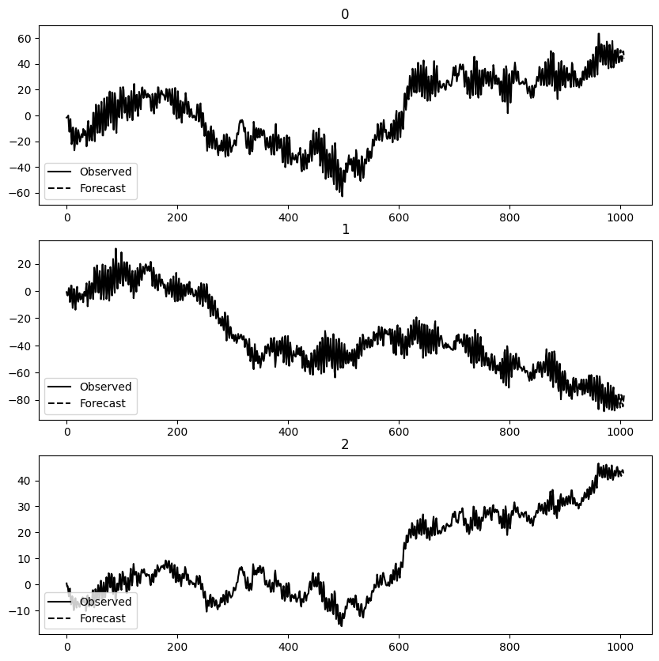

```python
vecm_res.predict(steps = 10, alpha = 0.05)
for text, values in zip (("forecast", "lower", "upper"), vecm_res.predict(steps = 10, alpha = 0.05)) :
  print(text+ ":", values, sep = "\n")
vecm_res.plot_forecast(steps = 10, plot_conf_int = False)
```

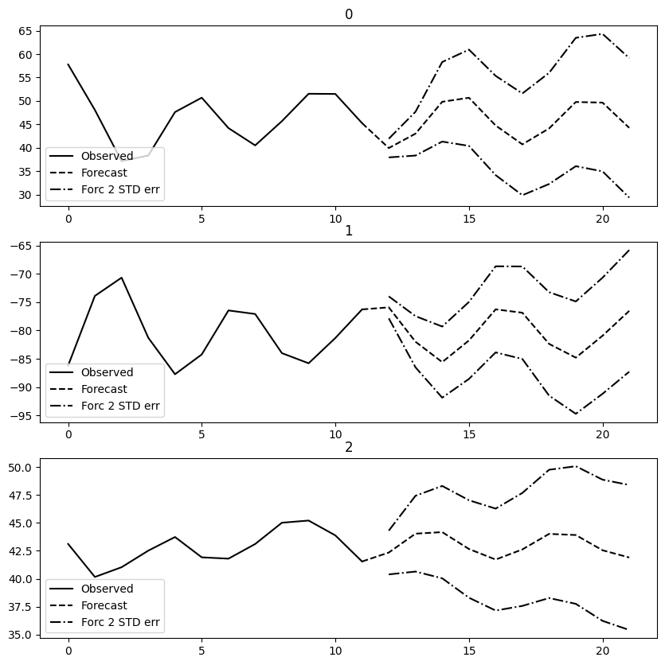

```python
vecm_res.plot_forecast(steps = 10, n_last_obs = 12)
plt.show()
```